# Test a Perceptual Phenomenon EEC

### Analyzing the Stroop Effect by Edgar Eguia

Perform the analysis in the space below. Remember to follow [the instructions](https://docs.google.com/document/d/1-OkpZLjG_kX9J6LIQ5IltsqMzVWjh36QpnP2RYpVdPU/pub?embedded=True) and review the [project rubric](https://review.udacity.com/#!/rubrics/71/view) before submitting. Once you've completed the analysis and write up, download this file as a PDF or HTML file and submit in the final section of this lesson.

(1) What is the independent variable? What is the dependent variable?

- Independent variable is the list of words (congruent words condition or incongruent words condition).
- Dependant variable is time of reaction to name the ink color of the words listed.

(2) What is an appropriate set of hypotheses for this task? Specify your null and alternative hypotheses, and clearly define any notation used. Justify your choices.

- H0 Mean of reaction time for congruent list of words will be less or equal than mean of reaction time for incongruent lists of words (Null).
- H1 Mean of reaction time for congruent list of words will be greater than mean of reaction time for incongruent list of words (Alternative).
- H0 μTc <= μTi or μTc - μTi <= 0
- H1 μTc > μTi or μTc - μTi > 0

I consider that if decision is Tcongruent > Tincongruent and the truth is Tcongruent <= Tincongruent, this will be Type I Error. I consider that if decision is Tcongruent <= Tincongruent and the truth is Tcongruent > Tincongruent, this will be Type II Error. These reasonings lead me to set hypotheses shown above.

We will consider sample provided by .csv file and make inference about the whole population (Let's say all subjects in the world). We will use a one-tailed test since sample is small (24 --> 24 < 30) and we don't know population standard deviation.

(3) Report some descriptive statistics regarding this dataset. Include at least one measure of central tendency and at least one measure of variability. The name of the data file is 'stroopdata.csv'.

```python
import pandas as pd
import numpy as np
import scipy.stats as sp
import matplotlib.pyplot as plt

%matplotlib inline
np.random.seed(50)

df = pd.read_csv('stroopdata.csv')
df.head(10)
```

|  | Congruent | Incongruent |
| --- | --- | --- |
| 0 | 12.079 | 19.278 |
| 1 | 16.791 | 18.741 |
| 2 | 9.564 | 21.214 |
| 3 | 8.630 | 15.687 |
| 4 | 14.669 | 22.803 |
| 5 | 12.238 | 20.878 |
| 6 | 14.692 | 24.572 |
| 7 | 8.987 | 17.394 |
| 8 | 9.401 | 20.762 |
| 9 | 14.480 | 26.282 |

**Number of total records (Sample) in dataframe:**

```python
numberRecords, columns = df.shape
print(numberRecords)
```

```
24
```

**Mean of Congruent and Incongruent times are computed**

```python
meanTC = df.Congruent.mean()
meanTI = df.Incongruent.mean()
```

```python
print(meanTC)
```

```
14.051124999999999
```

```python
print(meanTI)
```

```
22.015916666666666
```

**Standard deviations of congruent and incongruent times are computed.**

```python
standardDeviationTC = np.std(df.Congruent)
```

```python
print(standardDeviationTC)
```

```
3.484415712766633
```

```python
standardDeviationTI = np.std(df.Incongruent)
```

```python
print(standardDeviationTI)
```

```
4.696055134513317
```

(4) Provide one or two visualizations that show the distribution of the sample data. Write one or two sentences noting what you observe about the plot or plots.

**Histogram of sample data (1 sample) is shown (frequency of occurrence versus time of reaction "congruent").**

This plot shows how many subjects per time reaction occurred in the experiment considering congruent records.

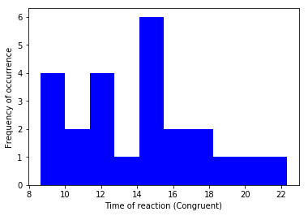

```python
plt.xlabel("Time of reaction (Congruent)")
plt.ylabel("Frequency of occurrence")
plt.hist(df.Congruent, color='blue');
```

**Distribution of sample data (bootstrapping / 10000 (24 subjects) samples with replacement) is shown (Occurrence versus time of reaction "congruent").**

```python
boot_meansC = []
for _ in range(10000):
    sample = df.sample(24, replace = True)
    boot_meansC.append(sample['Congruent'].mean())
```

We can observe that plotting samples means provides us a normal distribution (aprox.)

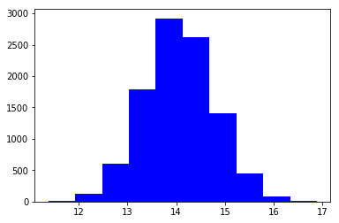

```python
plt.hist(boot_meansC, color='blue');
```

Original Sample's mean is almost equal to the mean of all samples means.

```python
df['Congruent'].mean() # Original Sample's mean (Congruent).
```

```
14.051124999999999
```

```python
np.mean(boot_meansC)  # Mean of all samples means (Congruent).
```

```
14.064216312500003
```

**Histogram of sample data (1 sample) is shown (frequency of occurrence versus time of reaction "incongruent").**

This plot shows how many subjects per time reaction occurred in the experiment considering incongruent records.

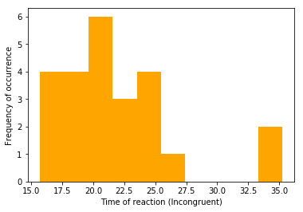

```python
plt.xlabel("Time of reaction (Incongruent)")
plt.ylabel("Frequency of occurrence")
plt.hist(df.Incongruent, color='orange');
```

**Distribution of sample data (bootstrapping / 10000 samples (24 subjects) with replacement) is shown (Occurrence versus time of reaction "incongruent").**

```python
boot_meansI = []
for _ in range(10000):
    sample = df.sample(24, replace = True)
    boot_meansI.append(sample['Incongruent'].mean())
```

We can observe that plotting samples means provides us a normal distribution (aprox.)

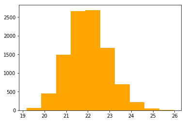

```python
plt.hist(boot_meansI, color='orange');
```

Original Sample's mean is almost equal to the mean of all samples means.

```python
df['Incongruent'].mean() # Original Sample's mean (Incongruent).
```

```
22.015916666666666
```

```python
np.mean(boot_meansI) # Mean of all samples means (Incongruent).
```

```
22.003312216666668
```

We can see that the time it takes to name ink colors for congruent condition (blue) is less than the time it takes for incongruent condition (orange).

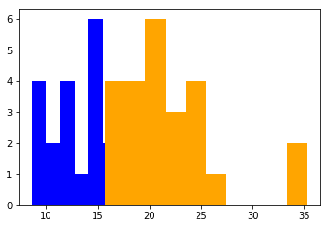

```python
plt.hist(df.Congruent, color='blue');
plt.hist(df.Incongruent, color='orange');
```

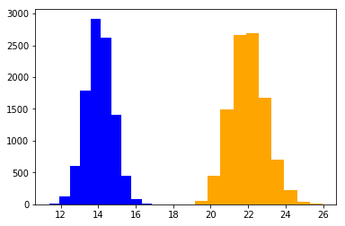

```python
plt.hist(boot_meansC, color='blue');
plt.hist(boot_meansI, color='orange');
```

(5) Now, perform the statistical test and report your results. What is your confidence level or Type I error associated with your test? What is your conclusion regarding the hypotheses you set up? Did the results match up with your expectations? **Hint:** Think about what is being measured on each individual, and what statistic best captures how an individual reacts in each environment.

We will set significance level "alpha" as 5% (0.05). We will perform statistical test (one-tailed test) by using python scipy.stats library.

```python
TC = np.array(df.Congruent)
```

```python
TI = np.array(df.Incongruent)
```

Since we will try to reject the null hypothesis in favor of the alternative hypothesis we must set the ttest_ind function first argument as TC (congruent data from sample) and second argument as TI (incongruent data from sample) so that μTc > μTi or μTc - μTi > 0 can be proved.

```python
sta, pval = sp.ttest_ind(TC, TI)
```

```python
print(sta)
```

```
-6.5322505539032285
```

```python
print(pval)
```

```
4.5949489622951854e-08
```

The test above shows us that statistic is -6.53 and p-value is 4.60e-08.

```python
(pval/2) < 0.025
```

```
True
```

(6) Optional: What do you think is responsible for the effects observed? Can you think of an alternative or similar task that would result in a similar effect? Some research about the problem will be helpful for thinking about these two questions!

I think delayed time reaction to incongruent words is due to human habits of associating objects or pictures to words; so in this case the picture (word color) tells our brains something different from what we are reading leading to confusion. A similar effect would be produced by numerical Stroop effect in which a digit is presented as big or small irrespective of its numerical value, then comparison of digits is carried out (incongruent trials leads to slower responses "let's say 7 is written in a smaller font size than 2" than congruent trials "let's say 2 is written in a smaller font size than 7).